# Complex Network - Exercises I

Student: Jorge Augusto Salgado Salhani

# USP: 8927418

## Question 1

Importing the needed library

```python
import networkx as nx
import numpy as np
import matplotlib.pyplot as plt
import scipy.stats as stats
```

This first graph will be made manually

```python
G = nx.Graph()
G.add_edge('1', '2')
G.add_edge('1', '4')
G.add_edge('2', '4')
G.add_edge('2', '3')
G.add_edge('3', '4')
G.add_edge('3', '6')
G.add_edge('3', '7')
G.add_edge('3', '5')
G.add_edge('6', '7')
```

Setting environment for graph drawing purpouse

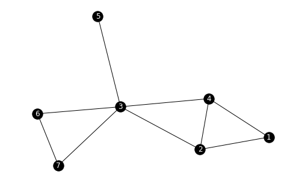

```python
labels = G.nodes()
pos = nx.spring_layout(G)
nx.draw(G, with_labels=True, font_color='white', node_color='black', pos=pos)
plt.show()
```

Item a) Degree distribution

```python
def degree_distribution(G, normalized):
    """
    FUNCTION:
    Calculate the degree distribution given a graph object
    from networkx

    PARAMETERS:
    G: networkx graph object
    normalized: boolean. Permits normalization of degree
    distribution

    RETURN:
    tuple: (x,y), representing the x-axis and y-axis in
    order to plot a histogram
    """

    #Getting the degree of each node as a dictionary
    nodes_degree = dict(G.degree())

    #Get the maximum degree value for delimiting the histogram
    max_degree = np.max(list(nodes_degree.values()))
    histogram_x_axis = np.arange(0, max_degree+1)
    histogram_y_axis = np.zeros(max_degree+1)

    #Counting the times a same-valued-degree is found
    for i in nodes_degree.values():
        histogram_y_axis[i]+=1

    #In normalized case, normalize all y-axis value
    if normalized == True:
        histogram_y_axis /= sum(histogram_y_axis)

    return histogram_x_axis, histogram_y_axis
```

```python
def bar_histogram_degree_plot(G, normalized=True):
    """
    FUNCTION:
    Plot, using matplotlib, the histogram degree distribution

    PARAMETERS:
    G: networkx graph object
    normalized: boolean setting the normalization

    RETURN:
    No return
    """

    #Calculate the degree distribution using the previous built
    #degree_distribution() function
    hist_x, hist_y = degree_distribution(G, normalized)

    #Plotting specification using matplotlib
    fig = plt.subplot(1,1,1)
    plt.bar(hist_x, hist_y, width=0.9)
    if normalized == True:
        plt.ylabel("Probability P(k)", fontsize=14)
    else:
        plt.ylabel("Number of nodes", fontsize=14)
    plt.title("Degree Distribution", fontsize=15)
    plt.xlabel("Degree k", fontsize=14)
    plt.show()
```

Firstly, we can plot a histogram not normalized. The y-axis indicate the number of nodes

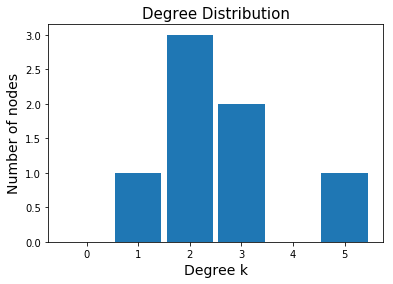

```python
bar_histogram_degree_plot(G, normalized=False)
```

And now, normalizing the distribution, we got the probability for degree distribution

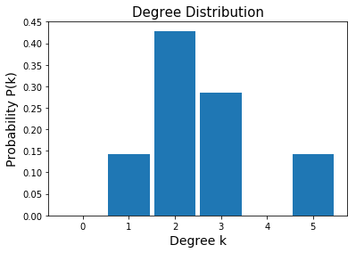

```python
bar_histogram_degree_plot(G, normalized=True)
```

Item b) Local clustering coefficient

Similarly to item a), first we can plot the number of nodes associated with each cluster coefficient. In order to compare with our expected result made by hand (pdf file resolution), we can print the dicitionary that associates each node number with its cluster coefficient (better than only cc values, once the list of nodes does not necessarily is sorted)

```
Cluster coefficient (node, cc) dictionary:
{'1': 1.0, '2': 0.6666666666666666, '4': 0.6666666666666666, '3': 0.2, '6': 1.0, '7': 1.0, '5': 0}
```

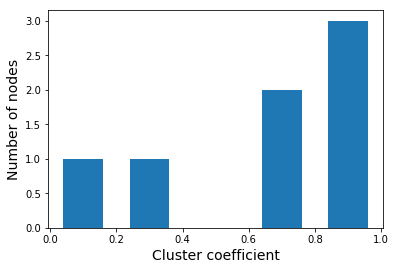

```python
#Using a bult_in method for calculate the clustering of
#a graph object
print('Cluster coefficient (node, cc) dictionary:')
print(nx.clustering(G))
cluster_coeff = nx.clustering(G).values()
plt.hist(cluster_coeff, bins=5, rwidth=.6)
plt.ylabel('Number of nodes', fontsize=14)
plt.xlabel('Cluster coefficient', fontsize=14)
plt.show()
```

Now, we consider the density probability distribution for cluster coefficient

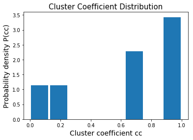

```python
#Calculate the cluster distribution, but now plotting the
#density probability distribution
plt.hist(cluster_coeff, bins=8, rwidth=.9, density=True)
plt.ylabel('Probability density P(cc)', fontsize=14)
plt.xlabel('Cluster coefficient cc', fontsize=14)
plt.title('Cluster Coefficient Distribution', fontsize=15)
plt.show()
```

Item c) Transitivity

```python
#Using a built_in method to calculate the transitivity of
#a graph object
transit = nx.transitivity(G)
print('Transitivity = %.5f'%transit)
```

```
Transitivity = 0.47368
```

Item d) Distance matrix

```python
#Once the nodes are not necessarily sorted, we make a
#list out of them and use the sort() method
node_list = list(G.nodes())
node_list.sort()

#Now we can use the built_in method floyd_warshal_numpy()
#that can calculate the distance matrix as we desired
dist_matrix = nx.floyd_warshall_numpy(G, nodelist=node_list)
print(dist_matrix)
```

```
[[0. 1. 2. 1. 3. 3. 3.]
 [1. 0. 1. 1. 2. 2. 2.]
 [2. 1. 0. 1. 1. 1. 1.]
 [1. 1. 1. 0. 2. 2. 2.]
 [3. 2. 1. 2. 0. 2. 2.]
 [3. 2. 1. 2. 2. 0. 1.]
 [3. 2. 1. 2. 2. 1. 0.]]
```

Item e) Shannon entropy for degree distribution

```python
#Firstly we must have the degree distribution, which can
#be obtained using our function degree_distribution()
hist_x, hist_y = degree_distribution(G, normalized=True)

#For each value in histogram y-value, we calculate its
#Shannon entropy and sum them all
shan_entropy = 0.
for i in hist_y:
    if i != 0.:
        shan_entropy += i*np.log(i)
shan_entropy *= -1
print('Shannon entropy for degree probability distribution = %.5f'%shan_entropy)
```

```
Shannon entropy for degree probability distribution = 1.27703
```

Item f) Second moment of degree distribution

```python
#By same arguments as before, we can use the function to
#get the degree distribution. Once the second moment can
#be find in therms of the first one, we calculate it here
hist_x, hist_y = degree_distribution(G, normalized=False)
count = 0.
mean = 0.
for i in hist_y:
    mean+=i
    count+=1
mean/=count
print('Mean value (first moment) = %.5f'%mean)
```

```
Mean value (first moment) = 1.16667
```

```python
#Now, taking the first moment, we can calculate the second
#one, also known as variance
var = 0
count = 0
for k in hist_y:
    var+=(k-mean)**2
    count+=1
var/=count
print('Variance (second moment) = %.5f'%var)
```

```
Variance (second moment) = 1.13889
```

## Question 2

Representing 'Les Miserables' graph unweighted

```python
def read_txt_and_Gcc(path, comment='%'):
    """
    FUNCTION:
    Read a file that contains node connections and their
    weights as float. Example of readable file
    ---------
    %This is an example file.
    %NodeA NodeB Weight
    0 1 0.5
    1 3 2.0
    2 3 1.2
    ---------

    Comments can be marked as wish ('%' is set as default)

    PARAMETERS:
    path: file path as string located in computer
    comment: char (or string) used in file to mark comments

    RETURN:
    tuple: (pos, G), representing the position object
    (networkx as nx, spring_layout()) for draw purpose and
    the Graph G itself made from file
    """
    G = nx.read_edgelist(path, comments=comment, nodetype=int, data=(('weight', float),))
    G = nx.convert_node_labels_to_integers(G, first_label=0)
    labels = G.nodes()
    pos = nx.spring_layout(G)
    G = G.to_undirected()
    G.remove_edges_from(G.selfloop_edges())
    Gcc = sorted(nx.connected_component_subgraphs(G), key=len, reverse=True)
    G = Gcc[0]
    return pos, G
```

```python
def read_gml_and_Gcc(path):
    """
    FUNCTION:
    Read a file gml type that contains node connections
    and their weights as float.

    PARAMETERS:
    path: file path as string located in computer

    RETURN:
    tuple: (pos, G), representing the position object
    (networkx as nx, spring_layout()) for draw purpose and
    the Graph G itself made from file
    """
    G = nx.read_gml(path)
    G = nx.convert_node_labels_to_integers(G, first_label=0)
    labels = G.nodes()
    pos = nx.spring_layout(G)
    G = G.to_undirected()
    G.remove_edges_from(G.selfloop_edges())
    Gcc = sorted(nx.connected_component_subgraphs(G), key=len, reverse=True)
    G = Gcc[0]
    return pos, G
```

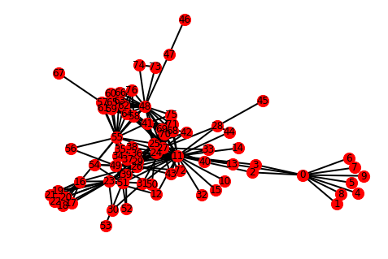

```python
#Using the built funtions above to read Les Miserables graph
#as .gml type file
pos, G_lesmis = read_gml_and_Gcc('/home/jorge/Documents/redes_complexas/lesmis/lesmis.gml')
nx.draw(G_lesmis, with_labels=True, node_color='red', node_size=200, pos=pos, width=2)
plt.show()
```

Representing 'Les Miserables' graph weighted

```python
#Wishing to make a weighted graph, we can write a file
#from Les Miserables edge list as we wish
nx.write_edgelist(G_lesmis, 'lesmis.txt')
G_lesmis = nx.read_edgelist("lesmis.txt", nodetype=int, edgetype=dict)
G_lesmis = G_lesmis.to_undirected()
G_lesmis.remove_edges_from(G.selfloop_edges())
```

```python
#Once we know weighted values are set as 'value', we can
#select all weights in order to make a graph with edges
#thicker or thinner according to its weight
all_weights = []
for (n1, n2, data) in G_lesmis.edges(data=True):
    all_weights.append(data['value'])

#To avoid multiple-valued funtion, we need to have a set
#(unique values from a list of elements)
unique_weights = list(set(all_weights))
```

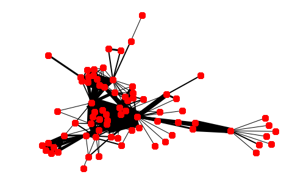

```python
#Now, for each weight, we can draw a line proportional to
#its value comparing to the unique_weights set
for w in unique_weights:
    weighted_edges = [(n1,n2) for (n1,n2,edge_attr) in G_lesmis.edges(data=True) if edge_attr['value'] == w]
    nx.draw(G_lesmis, pos=pos, edgelist=weighted_edges, node_size=100,
            width=w)
```

Now, using the data from 'http://networkrepository.com/eco-foodweb-baywet.php'

```python
#We can read the Florida ecosystem wet as well
pos, G_baywet = read_txt_and_Gcc('/home/jorge/Documents/redes_complexas/eco-foodweb-baywet/eco-foodweb-baywet.edges')
```

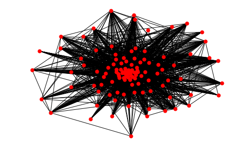

```python
#Showing the unweighted plot for baywet network
nx.draw(G_baywet, with_labels=False, node_color='red', node_size=50, pos=pos, width=1)
plt.show()
```

## Question 3

```python
def random_walk_on_graph(G_adj_matrix, n_steps, n_runs):
    """
    FUNCTION:
    Perform a random walk in a unweighted graph object
    from networkx

    PARAMETERS:
    G_adj_matrix: Adjacency matrix build from the graph
    n_steps: Number of steps wanted to be taken by the walker

    RETURN:
    list: representing the average visit of each node
    """
    #Build a vector with nodes in sorted order
    node_list = np.arange(len(G_adj_matrix))

    #Build a vector to store the average visit per node
    avg_visit_total = np.zeros(len(G_adj_matrix))

    #First loop consider the number of initial walker ramdomly
    #placed on graph
    for r in range(n_runs):

        #At each run, we choose a random node and build a vector
        #to hold the visits each one will have
        chosen_node = int(np.random.random()*len(node_list))
        avg_visit = np.zeros(len(G_adj_matrix))
        avg_visit[chosen_node]+=1
        #print(chosen_node)

        #Second loop consider the number of steps that will be
        #made by each walker
        for i in range(n_steps):

            #For an unweighted graph, the probability for each
            #node is equal and the sum of each row must be 1
            norm_prob = 1./(np.sum(G_adj_matrix[chosen_node]))
            #print(G_adj_matrix[chosen_node])

            #We first choose a random number in [0,1) interval
            rand_guess = np.random.random()
            #print(rand_guess)
            cumulative_guess = norm_prob
            j_position = 0

            #Third loop will sum the j_position element until
            #our cumulative_guess variable (which is summed
            #to the normalized probability, or norm_prob variable,
            #for each row) be greater than rand_guess variable
            for j in np.nditer(G_adj_matrix[chosen_node]):
                if j == 1:
                    if cumulative_guess <= rand_guess:
                        cumulative_guess+=norm_prob
                    else:
                        avg_visit[j_position]+=1
                        #print(j_position)
                        break
                j_position+=1

            #As we select our new randomly chosen node, we place
            #the new j_position element as our chosen_node variable
            chosen_node = j_position

        #Now we normalize the number of visited times for each
        #node and, then, add them to the avg_visit_total vector
        #print(avg_visit)
        avg_visit /= (n_steps+1)
        avg_visit_total += avg_visit

    #Finally, we normalize our last vector by the number of runs we
    #chose to make
    avg_visit_total /= (n_runs)
    #print(avg_visit_total)
    #print(np.sum(avg_visit_total))
    return avg_visit_total
```

In order to use our build function to perform the random walk, we must build the graph adacency matrix

```python
pos, G_lesmis = read_gml_and_Gcc('/home/jorge/Documents/redes_complexas/lesmis/lesmis.gml')
node_list = list(G_lesmis.nodes())
adj_matrix = nx.to_numpy_matrix(G_lesmis, nodelist=node_list)
```

Since we want to check the correlation between each node's degree and average visit number, we must separate a vector with thedegree of each one

```python
avg_visit = random_walk_on_graph(adj_matrix, n_steps=100, n_runs=100)

k_degree = []
for i in G_lesmis.degree():
    k_degree.append(i[1])
```

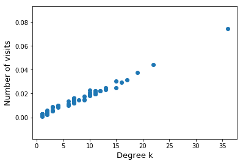

```python
#Now the average visit's list match with node degrees' list
plt.scatter(k_degree, avg_visit)
plt.xlabel("Degree k", fontsize=13)
plt.ylabel("Number of visits", fontsize=13)
plt.show()
```

And, finally, we can check the Pearson's correlation between these two measures

```python
pears_corr = stats.pearsonr(k_degree, avg_visit)[0]
print("Pearson correlation: %.5f"%pears_corr)
```

```
Pearson correlation: 0.99196
```

As we can see, these two graph measures are highly correlated, since correlation closer to 1 indicates it. This measure means that, the greater the degree of some node, greater the chance to it been visited randomly.

## Question 4

Item (a)

Defining a function to build the transition probability matrix given a adjacency matrix

```python
def build_transit_probab_matrix(adj_matrix):
    """
    FUNCTION:
    Build the Transition Probability Matrix

    PARAMETERS:
    adj_matrix: adjacency matrix built from the desired graph

    RETURN:
    numpy matrix 2x2: Transition probability matrix address
    """

    #Firstly, we can build a null vector in order to store
    #each element from our probability matrix
    total_nodes = len(adj_matrix)
    P_matrix = np.zeros((total_nodes, total_nodes))

    #These loop will set the principal diagonal as zero
    #and divide all other elements byt the sum of each
    #row (normalizing each of them)
    for i in range(total_nodes):
        for j in range(total_nodes):
            if adj_matrix[i,j] == 0:
                P_matrix[i,j] = 0
            else:
                P_matrix[i,j] = adj_matrix[i,j]/np.sum(adj_matrix[i])
    return P_matrix
```

Defining a function to calculate the n-th power of the transition probability matrix (construct before)

```python
def powers_of_matrix(matrix, n):
    """
    FUNCTION:
    Calculate the n-the power for a given matrix

    PARAMETERS:
    matrix: matrix desired to has its n-th power
    calculate

    n: power to be put over matrix

    RETURN:
    numpy matrix 2x2: matriz raised to n-th power
    """
    mat_i = matrix
    for i in range(n):
        mat_i = np.matmul(mat_i, matrix)
    return mat_i
```

```python
adj_matrix = nx.to_numpy_matrix(G, nodelist=list(G.nodes()))
prob_matrix = build_transit_probab_matrix(adj_matrix)
```

Now we can perform the powers calculation for crescent n

```python
prob_mat_m = powers_of_matrix(prob_matrix, 50)
print(prob_mat_m)
```

```
[[0.11111111 0.16666667 0.16666667 0.27777777 0.11111111 0.11111111
  0.05555556]
 [0.11111111 0.16666667 0.16666667 0.27777778 0.11111111 0.11111111
  0.05555555]
 [0.11111111 0.16666667 0.16666667 0.27777778 0.11111111 0.11111111
  0.05555555]
 [0.11111111 0.16666667 0.16666667 0.27777777 0.11111111 0.11111111
  0.05555556]
 [0.11111111 0.16666667 0.16666667 0.27777778 0.11111111 0.11111111
  0.05555556]
 [0.11111111 0.16666667 0.16666667 0.27777778 0.11111111 0.11111111
  0.05555556]
 [0.11111111 0.16666666 0.16666666 0.27777778 0.11111111 0.11111111
  0.05555555]]
```

We can note that for n=50 all collumns are already approximatelly equal, so in limit case where n goes to infinity, all lines and collumns are exact the same. Once the n-th power of a transit probability matrix indicates the number of paths that, after n steps, can be reached from i to j (where i,j stands for the row, collumn from adjacency matrix), when we consider a large number of steps and since the number of paths in a graph is finite, after n big, the number of paths that we can arrive at a fixed j from any i is nearly the same, therefore all collumns converges to the same value.

Item (b)

For this item we need the adjacency and distance matrix, at first

```python
node_list_lesmis = list(G_lesmis.nodes())
node_list_lesmis.sort()
dist_matrix_lesmis = nx.floyd_warshall_numpy(G_lesmis, nodelist=node_list_lesmis)
adj_matrix_lesmis = nx.to_numpy_matrix(G_lesmis, nodelist=node_list_lesmis)
```

Now, we want to make a scatter plot for each matrix element of A(i,j)^3 and D(i,j)

```python
#Calculating the 3rd power of adjacency matrix
adj_mat_pow_m = powers_of_matrix(adj_matrix_lesmis, 3)

#Each vector will store the matrix element for A^3(i,j) in x,
#and D(i,j) in y
x_scat = []
y_scat = []
total_nodes_lesmis = len(dist_matrix_lesmis)
for i in range(total_nodes_lesmis):
    for j in range(total_nodes_lesmis):

        #Each i,j element wll be added to the vectors
        x_scat.append(adj_mat_pow_m[i,j])
        y_scat.append(dist_matrix_lesmis[i,j])
```

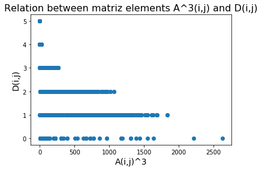

```python
plt.scatter(x_scat, y_scat)
plt.title("Relation between matriz elements A^3(i,j) and D(i,j)", fontsize=16)
plt.ylabel('D(i,j)', fontsize=14)
plt.xlabel('A(i,j)^3', fontsize=14)
plt.show()
```

Once we know that the a(i,j) element from adjacency matrix raised to the n-th power gives us the number of paths between nodes i and j that require n steps to be complete, this relation shown above can be understand as the relation between static distance between i and j (D(i,j), on y axis) and the number of paths from i to j that requires n=3 steps.

Item (c)

In order to vary the n-th power of transit probability matrix, we can use our two before-defined functions

```python
#Build the transit probability matrix out of distance matrix
prob_mat_lesmis = build_transit_probab_matrix(adj_matrix_lesmis)
n_pow = 100

#Keep vector for crescent n (powers transit matrix will be raised to)
#and for each pearson's correlation calculated by each n
x_scat_pearson = np.arange(n_pow)
y_scat_pearson = []
for n in range(n_pow):
    #Calculate the power for each crescent number n
    prob_mat_pow_m = powers_of_matrix(prob_mat_lesmis, n)
    x_scat = []
    y_scat = []
    total_nodes_lesmis = len(dist_matrix_lesmis)
    for i in range(total_nodes_lesmis):
        for j in range(total_nodes_lesmis):
            x_scat.append(prob_mat_pow_m[i,j])
            y_scat.append(dist_matrix_lesmis[i,j])

    #Calculate, at the end, pearson's correlation between elements of
    #D(i,j) distance and P^n(i,j) prabability matrix
    y_scat_pearson.append(stats.pearsonr(x_scat, y_scat)[0])
```

Now, we can examine how pearson's correlation evolves with power n of P(i,j) matrix

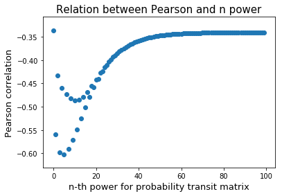

```python
plt.scatter(x_scat_pearson, y_scat_pearson)
plt.title('Relation between Pearson and n power', fontsize=15)
plt.xlabel('n-th power for probability transit matrix', fontsize=13)
plt.ylabel('Pearson correlation', fontsize=13)
plt.show()
```

As we can see, there is a global minimum that pearson's correlation is greater (in absolute value). In order to relates this quantity in terms of some other property of the graph, such as the shortest pathlenght and the diameter

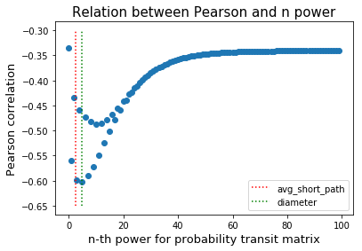

```python
plt.scatter(x_scat_pearson, y_scat_pearson)
plt.title('Relation between Pearson and n power', fontsize=15)
plt.xlabel('n-th power for probability transit matrix', fontsize=13)
plt.ylabel('Pearson correlation', fontsize=13)
sp = nx.average_shortest_path_length(G_lesmis)
diam = nx.diameter(G_lesmis)
plt.vlines(sp, -0.65, -0.30, colors='r',linestyle='dotted',label='avg_short_path')
plt.vlines(diam, -0.65, -0.30, colors='g',linestyle='dotted',label='diameter')
plt.legend()
plt.show()
```

It can be noted that both measures are closed to the global minimum, however the diameter really matches with the n-th power of the probability matrix that minimizes the Pearson's correlation. We can do this for the other database such as euroroad and network scientists colaborators

For this purpouse, we can build a function that returns the vector of n Pearson's correlation, calculated for each n-th power of transit probability matrix

```python
def pearson_and_nth_power_transit_probab(G, n_pow):
    """
    FUNCTION:
    Calculates the pearson's correlation for each power of the transit probability matrix associated
    to the adjacency matrix of graph G. Thecorrelation is made between transit probability raised to n and
    Distance matrix

    PARAMETERS:
    G: graph object from networkx
    n_pow: power of transit probability matrix desired

    RETURN:
    tuple: (x_scat, y_scat) representing the two vectors containing the sequencial numbers from 0 to n_pow, and the
    pearson's correlation for each x value. These two vectors can be used for plot purposes
    """
    node_list = list(G.nodes())
    total_nodes = len(node_list)
    node_list.sort()

    dist_matrix = nx.floyd_warshall_numpy(G, nodelist=node_list)
    adj_matrix = nx.to_numpy_matrix(G, nodelist=node_list)

    prob_mat = build_transit_probab_matrix(adj_matrix)

    #Keep vector for crescent n (powers transit matrix will be raised to)
    #and for each pearson's correlation calculated by each n
    x_scat_pearson = np.arange(n_pow)
    y_scat_pearson = []
    for n in range(n_pow):
        #Calculate the power for each crescent number n
        prob_mat_pow_m = powers_of_matrix(prob_mat, n)
        x_scat = []
        y_scat = []
        for i in range(total_nodes):
            for j in range(total_nodes):
                x_scat.append(prob_mat_pow_m[i,j])
                y_scat.append(dist_matrix[i,j])

        #Calculate, at the end, pearson's correlation between elements of
        #D(i,j) distance and P^n(i,j) prabability matrix
        y_scat_pearson.append(stats.pearsonr(x_scat, y_scat)[0])
    return x_scat_pearson, y_scat_pearson
```

```python
pos, G_netscience = read_gml_and_Gcc('/home/jorge/Documents/redes_complexas/netscience/netscience.gml')
x_pears_netsc, y_pears_netsc = pearson_and_nth_power_transit_probab(G_netscience, 200)
```

```python
pos, G_euroroad = read_txt_and_Gcc('/home/jorge/Documents/redes_complexas/subelj_euroroad/out.subelj_euroroad_euroroad')
x_pears_euro, y_pears_euro = pearson_and_nth_power_transit_probab(G_euroroad, 200)
```

```
Aaverage shortest path:  6.041867347935949
Diameter:  17
```

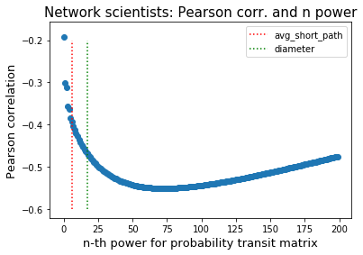

```python
plt.scatter(x_pears_netsc, y_pears_netsc)
plt.title('Network scientists: Pearson corr. and n power', fontsize=15)
plt.xlabel('n-th power for probability transit matrix', fontsize=13)
plt.ylabel('Pearson correlation', fontsize=13)
sp = nx.average_shortest_path_length(G_netscience)
diam = nx.diameter(G_netscience)
print("Aaverage shortest path: ",sp)
print('Diameter: ', diam)
plt.vlines(sp, -0.6, -0.2, colors='r',linestyle='dotted',label='avg_short_path')
plt.vlines(diam, -0.6, -0.2, colors='g',linestyle='dotted',label='diameter')
plt.legend()
plt.show()
```

```
Average shortest path:  18.39514614059391
Diameter:  62
```

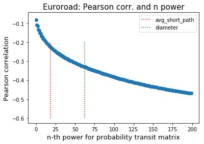

```python
plt.scatter(x_pears_euro, y_pears_euro)
plt.title('Euroroad: Pearson corr. and n power', fontsize=15)
plt.xlabel('n-th power for probability transit matrix', fontsize=13)
plt.ylabel('Pearson correlation', fontsize=13)
sp = nx.average_shortest_path_length(G_euroroad)
diam = nx.diameter(G_euroroad)
print('Average shortest path: ', sp)
print('Diameter: ', diam)
plt.vlines(sp, -0.6, -0.2, colors='r',linestyle='dotted',label='avg_short_path')
plt.vlines(diam, -0.6, -0.2, colors='g',linestyle='dotted',label='diameter')
plt.legend()
plt.show()
```

```
Average Shortest path:  2.6411483253588517
Diameter:  5
```

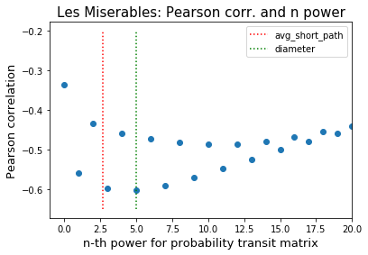

```python
x_pears_lesmis, y_pears_lesmis = pearson_and_nth_power_transit_probab(G_lesmis, 200)
plt.scatter(x_pears_lesmis, y_pears_lesmis)
plt.title('Les Miserables: Pearson corr. and n power', fontsize=15)
plt.xlabel('n-th power for probability transit matrix', fontsize=13)
plt.ylabel('Pearson correlation', fontsize=13)
plt.xlim(-1,20)
sp = nx.average_shortest_path_length(G_lesmis)
diam = nx.diameter(G_lesmis)
print('Average Shortest path: ',sp)
print('Diameter: ', diam)
plt.vlines(sp, -0.65, -0.2, colors='r',linestyle='dotted',label='avg_short_path')
plt.vlines(diam, -0.65, -0.2, colors='g',linestyle='dotted',label='diameter')
plt.legend()
plt.show()
```

As can be noted, not all graphs have the same property as Les Miserables characters links. This could be due to the small world characteristic of Les Miserables graph, which does not occur in the other ones.

A small world graph can be thought as a graph in which each node does not connect with each other, but its neighbors do. In other words, exists a typical distance L such that, starting from a i-th node, it is possible to arrive to any j-th by L steps. Considering this concept and knowing that the diameter of a graph represents the longest short path between any two (i,j) node pair, by the last plot above, the greatest (absolute value) correlation between n (P(i,j)^n) and D (D(i,j)) occurs at n = 5, we can conclude that the number of paths that leads i to j nodes after n=5 steps closely relates to their distances which is also the longest short path between them.

On the other hand, since pearson's correlation is lower (more negative), that means that for n=5, e.g., for a big number of transit probability paths that exists between nodes i and j that can be taken by n=5 steps, smaller is the distance between them.

## Question 5

Canceled

## Question 6

Item (a)

In this question, we must determine the cumulative distribution for each network. For easily view, we can define a function to facilitate our plot purposes.

```python
def log_degree_plot(G, normalized=True):
    """
    FUNCTION:
    Plot, using matplotlib, the degree distribution in
    a log-log cartesian map

    PARAMETERS:
    G: networkx graph object
    normalized: boolean setting the normalization

    RETURN:
    No return
    """

    #Calculate the degree distribution using the previous built
    #degree_distribution() function
    hist_x, hist_y = degree_distribution(G, normalized)

    #Plotting specification using matplotlib
    fig, ax = plt.subplots()
    plt.plot(hist_x, hist_y, marker='o', linestyle="None")
    ax.set_yscale('log')
    ax.set_xscale('log')
    plt.title("Degree Distribution", fontsize=15)
    plt.ylabel("Probability P(k)", fontsize=14)
    plt.xlabel("Degree k", fontsize=14)
    plt.show()
```

```python
def cumulative_distribution_plot(G, num_bins=50):
    """
    FUNCTION:
    Build a vector containing the values for constructing a cumulative distribution

    PARAMETERS:
    distr: List containing the values about which the cumulative
    distribution is going to be build

    RETURN:
    No return
    """

    hist_x, hist_y = degree_distribution(G, normalized=False)
    n, bins = np.histogram(hist_y, bins=num_bins, density=True)
    cdf = np.cumsum(n)
    plt.plot(bins[1:], cdf/cdf[-1])
    plt.title('Cumulative Distribution', fontsize=15)
    plt.xlabel("Degree k", fontsize=13)
    plt.ylabel('Probability P(k) > k', fontsize=13)
    plt.show()
```

Now, we can read each network with our read functions built before and show the graph of each respective unweighted network

```python
pos, G_euroroad = read_txt_and_Gcc('/home/jorge/Documents/redes_complexas/subelj_euroroad/out.subelj_euroroad_euroroad')
```

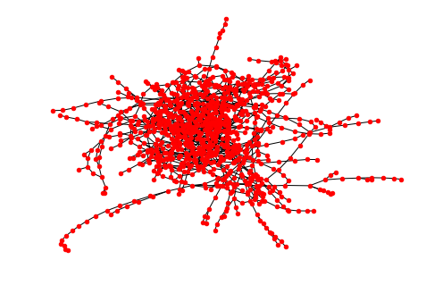

```python
nx.draw(G_euroroad, with_labels=False, node_color='red', node_size=20, pos=pos)
plt.show()
```

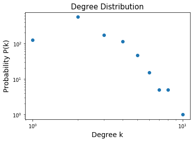

```python
log_degree_plot(G_euroroad, normalized=False)
```

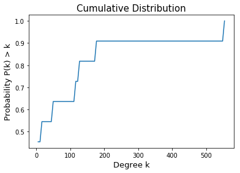

```python
cumulative_distribution_plot(G_euroroad, 100)
```

Item (b)

```python
pos, G_facebook = read_txt_and_Gcc('/home/jorge/Documents/redes_complexas/facebook_combined.txt')
```

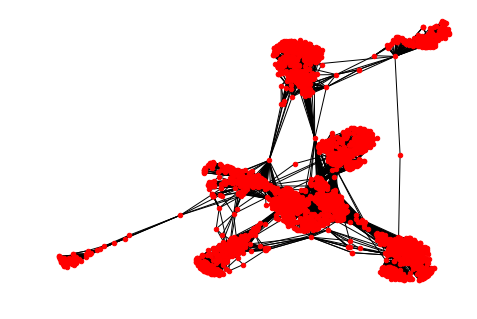

```python
nx.draw(G_facebook, with_labels=False, node_color='red', node_size=20, pos=pos)
plt.show()
```

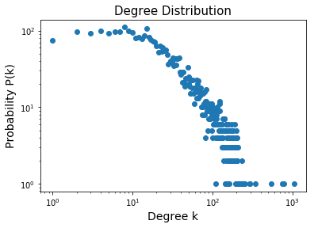

```python
log_degree_plot(G_facebook, normalized=False)
```

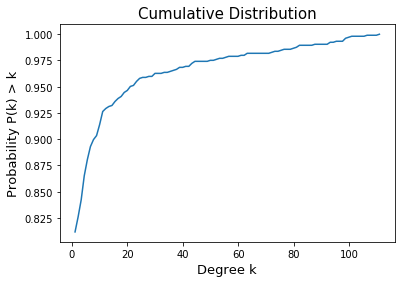

```python
cumulative_distribution_plot(G_facebook, 100)
```

Item (c)

```python
pos, G_netscience = read_gml_and_Gcc('/home/jorge/Documents/redes_complexas/netscience/netscience.gml')
```

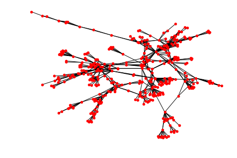

```python
nx.draw(G_netscience, with_labels=False, node_color='red', node_size=20, pos=pos)
plt.show()
```

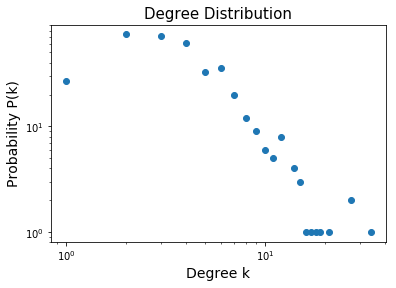

```python
log_degree_plot(G_netscience, normalized=False)
```

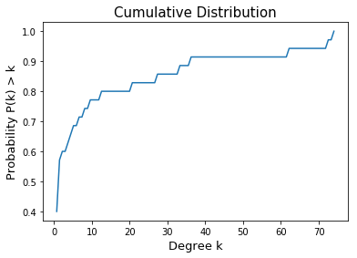

```python
cumulative_distribution_plot(G_netscience, 100)
```

Item (d)

```python
pos, G_hamster = read_txt_and_Gcc('/home/jorge/Documents/redes_complexas/petster-friendships-hamster/out.petster-friendships-hamster-uniq')
```

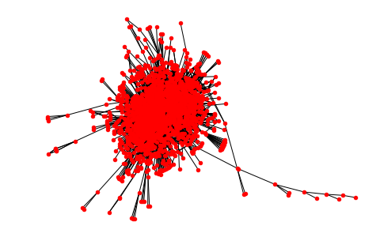

```python
nx.draw(G_hamster, with_labels=False, node_color='red', node_size=20, pos=pos)
plt.show()
```

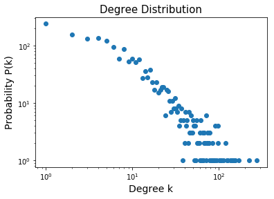

```python
log_degree_plot(G_hamster, normalized=False)
```

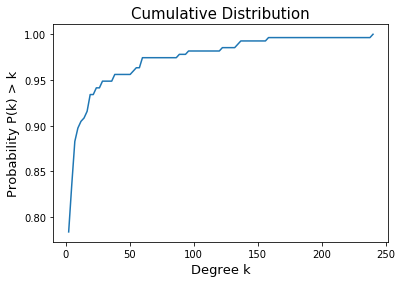

```python
cumulative_distribution_plot(G_hamster, 100)
```

## Question 7

Measures "average Cluster Coefficient" and "Transitivity" are displayed with other ones on Question 9

## Question 8

## Question 9

Fist, we must read each database and store separately, once we will need all of them simultaneously to build our table

```python
pos_euro, G_euroroad = read_txt_and_Gcc('/home/jorge/Documents/redes_complexas/subelj_euroroad/out.subelj_euroroad_euroroad')
```

```python
pos_face, G_facebook = read_txt_and_Gcc('/home/jorge/Documents/redes_complexas/facebook_combined.txt')
```

```python
pos_astro, G_astro = read_txt_and_Gcc('/home/jorge/Documents/redes_complexas/ca-AstroPh/out.ca-AstroPh')
```

```python
pos_hams, G_hamster = read_txt_and_Gcc('/home/jorge/Documents/redes_complexas/petster-friendships-hamster/out.petster-friendships-hamster-uniq')
```

The table will be made using Pandas library. In order: NK: Number of nodes AVG_K: average degree MOM2: second moment of degree distribution AVG_CC: average cluster coefficient TRANST: Transitivity AVG_SP: average shortest pathlength DIAMT: Diameter

The row sequences will holds for: 0: Euroroad map 1: Facebook relations 2: astrophysics arXiv contributions 3: Hamster petshop

```python
NK = [] #Stores number of nodes
AVG_K = [] #Stores the average degree
MOM2 = [] #Stores second moment
AVG_CC = [] #Stores average cluster coefficient
TRANST = [] #Stores transitivity
AVG_SP = [] #Stores average shortest pathlength
DIAM = [] #Stores diameter

for i in range(4):
    if i == 0:
        G_i = G_euroroad
    elif i == 1:
        G_i = G_facebook
    elif i == 2:
        G_i = G_astro
    else:
        G_i = G_hamster

    #Number of nodes
    total_nodes = len(list(G_i.nodes()))
    NK.append(total_nodes)

    #Average degree
    k_degree = []
    for node in G_i.degree():
        k_degree.append(node[1])

    norm = sum(k_degree)/len(k_degree)
    AVG_K.append(norm)

    #Second moment
    hist_x, hist_y = degree_distribution(G_i, normalized=False)
    count = 0.
    mean = 0.
    for i in hist_y:
        mean+=i
        count+=1
    mean/=count

    var = 0
    count = 0
    for k in hist_y:
        var+=(k-mean)**2
        count+=1
    var/=count
    MOM2.append(var)

    #Average cluster coefficient
    total_nodes = len(list(G_i.nodes()))
    cluster_coeff = nx.clustering(G_i).values()
    avg_cc = sum(cluster_coeff)/total_nodes
    AVG_CC.append(avg_cc)

    #Transitivity
    transit = nx.transitivity(G_i)
    TRANST.append(transit)

    #Average Shortest pathlength
    avg_sp = nx.average_shortest_path_length(G_i)
    AVG_SP.append(avg_sp)

    #Diameter
    diam = nx.diameter(G_i)
    DIAM.append(diam)
```

```python
#NK: Number of nodes AVG_K: average degree MOM2: second moment of degree distribution AVG_CC: average cluster coefficient
#TRANST: Transitivity AVG_SP: average shortest pathlength DIAMT: Diameter

import pandas as pd
df = pd.DataFrame({'K':NK,'AVG_K':AVG_K,'MOM2':MOM2,'AVG_CC':AVG_CC,'TRANST':TRANST,'AVG_SP':AVG_SP,'DIAM':DIAM})
print(df)
```

```
       K      AVG_K          MOM2    AVG_CC    TRANST     AVG_SP  DIAM
0   1039   2.793907  24556.247934  0.018906  0.035255  18.395146    62
1   4039  34.837245    193.744646  0.605547  0.519174   3.692507     8
2  17903  24.873363  20469.194181  0.632823  0.317778   4.194012    14
3   1788  24.087660    590.972829  0.143305  0.090369   3.452640    14
```

In order to make the discussion more comprehensive, we are going to explain each measurement by comparing only the two graphs that have the most difference between their numeric values. For example, for total node amount, we will compare only graphs of index 0 (euroroad) and of index 2 (astrophysics).

For average degree (AVG_K), we can assure that euroroad (index 0) streets's map have the lower number of connection between each node, on average, and facebook relations (index 1) has the greater number of connections, so Facebook friends' have more connections (undirected) than cities from Europe (connected by road). This can also be tought on a way such that it is easier to connect to someone else via facebook friend's than to connect to someone via linked cities on Europe.

Another measurement that goes through the same graph characteristic as the one described above is the graph diameter (DIAM). Euroroad (index 0) has the highest diameter and Facebook (index 1), the lowest, most probably due to the the fact that there is no shortcut between two far away cities (which does note happen on Facebook, since there is no physical barrier limiting the existence of shortcuts between two people on internet) and the longest shortest path (short-sentence definition of diameter) between two cities is numerically high.

The average clustering coefficient (AVG_CC), on the other hand, is high for astrophysics collaborators (index 2) and low for euroroad (index 0). Even though it measures different things than those considered on average degree, second moment and diameter, it can be explain by arguments analogous to those before-mentioned. Once AVG_CC is related to the number of connections each of the neighbors from a chosen node have, a road map connecting cities would probably have only neighbor cities that have no higher link account than themselves, once cities have a limited space to make inter-municipal links and low-connected ones would not 'interact' with big towns, such graph would probably has low AVG_CC, as we can see on euroroad. The opposite arguments can be used for astrophysics collaborations, which is a social (professional) network, resulting on a AVG_CC numerically bigger than euroroad's.

Finally, transitivity is highest on Facebook's relations (index 1) and lowest on euroroad (index 0), as mostly of the other measures. The explanation for this is analogous to those before. Once transitivity is related to a inductive connection possibility, namely, if the i-th node is connected to j-th node, which is connected to k-th node, then transitivity measurement relates to the probability that node i links to node k, than we can also states that inter-municipal roads have a not so great chance to have this property, since every town tends to get to the bigger ones by paths that make no shortcuts throughout cities that are not on the direct way and, because of that, existing connections between cities A and B, ans B and C, does not have a big chance to imply that A is linked to C. On the other hand, it is more likely to happpen on social media, based on arguments already placed on this discussion.